# Homework 7 - BIOS 6643

Dominic Adducci

2023-10-31

## Exam Q3

Write out the likelihood for this marginal model. What is the distribution of the outcome for subject i including the mean and variance? Write out the structure of the marginal variance. From the previous question on the exam the model was a linear mixed effects model with a linear trend for observation year and use a marginal compound symmetry model to incorporate correlation between the cognitive measures on the same person.

Likelihood:
$$\frac{1}{(2\pi)^{n_i}}|V_i|^{-1/2}(\alpha)|exp\left[-\frac{1}{2}(Y_i-X_i\beta)^TV_i(\alpha)^{-1}(Y_i-X_i\beta)\right]$$
Mean:
$$E[Y_{i}]=X_i\beta$$
Variance:
$$Var[Y_{i}]=R_i$$
Where $i = 1...N$; N = Number of subjects.

Marginal variance structure $V_i = R_i$:
$$\begin{bmatrix}
\sigma_1^2 + \sigma^2 & \sigma_1^2 & \sigma_1^2 &
\sigma_1^2 & \sigma_1^2 & \sigma_1^2 & \sigma_1^2 &
\sigma_1^2 \\
\sigma_1^2 & \sigma_1^2 + \sigma^2 & \sigma_1^2 &
\sigma_1^2 & \sigma_1^2 & \sigma_1^2 & \sigma_1^2 &
\sigma_1^2 \\
\sigma_1^2 & \sigma_1^2 & \sigma_1^2 + \sigma^2 &
\sigma_1^2 & \sigma_1^2 & \sigma_1^2 & \sigma_1^2 &
\sigma_1^2 \\
\sigma_1^2 & \sigma_1^2 & \sigma_1^2 & \sigma_1^2 +
\sigma^2 & \sigma_1^2 & \sigma_1^2 & \sigma_1^2 &
\sigma_1^2 \\
\sigma_1^2 & \sigma_1^2 & \sigma_1^2 & \sigma_1^2 &
\sigma_1^2 + \sigma^2 & \sigma_1^2 & \sigma_1^2 & \sigma_1^2
\\
\sigma_1^2 & \sigma_1^2 & \sigma_1^2 & \sigma_1^2 &
\sigma_1^2 & \sigma_1^2 + \sigma^2 & \sigma_1^2 & \sigma_1^2
\\
\sigma_1^2 & \sigma_1^2 & \sigma_1^2 & \sigma_1^2 &
\sigma_1^2 & \sigma_1^2 & \sigma_1^2 + \sigma^2 & \sigma_1^2
\\
\sigma_1^2 & \sigma_1^2 & \sigma_1^2 & \sigma_1^2 &
\sigma_1^2 & \sigma_1^2 & \sigma_1^2 & \sigma_1^2 + \sigma^2
\end{bmatrix}$$

## Exam Q4

The MLE of the beta coefficients conditional on alpha (the parameters in the variance) is: $\hat{\beta}(\alpha)=\Sigma_i^NX_i^TV_i^{-1}(\alpha)X_i^{-1}\Sigma_i^NX_i^TV_i^{-1}(\alpha)Y_i$. Since $\alpha$ is unknown we need to estimate it. What are the two approaches commonly used to estimate $\alpha$? List a strength and a weakness for each approaches.

The two approaches are Maximum Likelihood (ML) and Restricted Maximum Likelihood (REML).

**MLE**

Strength: LRT is applicable when using ML, allowing for more robust hypothesis testing.

Weakness: Variance estimates are biased downward by a factor of (n-p)/p. This is more significant with smaller sample sizes.

**REML**

Strength: Removes $\beta$ from variance estimates, negating the bias present with the ML method, providing an unbiased estimate for $\alpha$.

Weakness: Not under full theory framework, do not have likelihood for a LRT due to restricted variance.

## Question 0

What is the project you want to do for your project?

In order of preference: 2,3,1.

## Question 1

We have learned that for marginal GLM modeling we use GEE for estimation. GEE is based on defining moments (mean and variance and pairwise correlations) and a least squares like objective function rather than writing down a full joint likelihood and using MLE. In 2-3 sentences, explain the advantages of GEE compared to MLE in this context.

The advantage of GEE compared to MLE in this context is that GEE does not require a distributional assumption. This means the GEE model is simpler compared to the GLM model.

## Question 2

On page 358 in FLW it states at the end of the development of the sandwich estimator that if we model $V_i$ correctly, meaning the working correlation structure is correct and $V_i = \Sigma_i$, and $Cov(\hat{\beta})=B^{-1}$ instead of $Cov(\hat{\beta})=B^{-1}MB^{-1}$, where $B$ and $M$ are defined at the top of page 358 in your book. Show that this equality is true.
$$B = \Sigma_i^N D_i^TV_i^{-1}D_i$$
$$M =
\Sigma_i^ND_i^TV_i^{-1}Cov(Y_i)V_i^{-1}D_i$$
$$V_i = \Sigma_i^N = Cov(Y_i)$$
$$Cov(\hat{\beta})=B^{-1}MB^{-1}$$
Simplifying M:
$$M = \Sigma_i^N
D_i^TV_i^{-1}V_iV_i^{-1}D_i=\Sigma_i^ND_i^TV_i^{-1}D_i=B$$
Plugging in M for the covariance equation:
$$Cov(\hat{\beta}) =
B^{-1}MB^{-1}=B^{-1}BB^{-1}=B^{-1}I=B^{-1}$$
Because $BB^{-1}$ is equal to the identity matrix.

## Question 3

A study is planned where data will be collected on asthmatic subjects on every weekday for one month. There are two outcome measures of interest, (i) medication use counts and (ii) FEV1. You are the statistician and the PI is looking for your suggestions about models to use.

#### Part A

If it is anticipated that responses within subjects over time are serially correlated (but with some decay the further measurements are apart) for both outcomes, which R function (and package) would you suggest using to fit the data?

*Outcome (i):*

The outcome of interest is count data. For this scenario we can use the “gls” function in R from the “nlme” package. Because this is count data we can specify the link function to be “poisson(link =”log”)“. Because there is some decay in correlation the further away measurements are from each other an AR1 correlation structure will be used.

*Outcome (ii):*

The outcome of interest in this case is continuous. For this scenario we can use the “geem2” function in R from the “mmmgee” package. This is continuous data meaning we do not need to specify the link function (the default in geem2 is Gaussian). We can again specify the correlation as AR1 to account for the decay in correlation the further apart time points are.

#### Part B

Suppose that we now consider an indicator of whether subjects are on medication A or medication B (A use = 0,B use = 1). The investigator is interested in population level effects of treatment use on the outcomes. Will a marginal model have the correct interpretation of the treatment effects for each outcome? Explain.

Because of the way the medication variable is coded medication A will be the reference which medication B is compared against. The interpretation of treatment effect will be B relative to A. For outcome (i) the population level interpretation will relate to the number of times medication is needed for B compared to A. For outcome (ii) the population level interpretation will relate to the FEV1 value when using treatment B vs using treatment A.

#### Part C

What are the drawbacks of using a marginal approach?

The drawbacks of a marginal approach are that you can only make population mean interpretation, you cannot make inferences on the subject level.

#### Part D

Will the marginal approach allow us to quantify and study subject-to-subject variation in the weekly trends?

No, you would not be able to quantify subject-to-subject variation within a treatment group because the marginal model only makes inferences for the population averages. In other words you can make inferences between treatments, but you cannot make inferences between subjects within the treatment groups.

## Question 4

A randomized double blink trial of 294 patients was conducted to compare 2 oral treatments, corresponding to Itraconazole (treat=0) Terbinafine (treat=1), for toenail infection. The response variable was the binary indicator for presence of onycholysis (separation of the nail plate from the nail bed). Patients were evaluated for onycholysis at baseline (week 0) and at weeks 4,8,12,24,36, and 48. Suppose the interest is in finding the effect of treatment on changes in risk of onycholysis over time. Response is a binary indicator for moderate or severe (response=1) versus none or mild (response=0) onycholysis.

#### Part A

Fit a GEE model with month and the interaction between treatment and month, and fit the model using three different working correlation structures (AR(1), independence, and exchangeable). Assume that there is no difference between treatments at baseline. Assume the scale parameter $\phi = 1$. Interpret the results of the AR(1) model.

*AR(1) Model:*

```r
onycholysis_ar1 <- geem2(response ~ month + treat:month, id = id_vector,
                        data = onycholysis_data,
                        family = binomial(link = "logit"),
                        corstr = "ar1", init.phi = 1, scale.fix = TRUE)

onycholysis_ar1_sum <- summary(onycholysis_ar1)

# 95% CI for the month estimate.
month_lower <- exp(onycholysis_ar1_sum$coef[2,1] -
                     onycholysis_ar1_sum$coef[2,3]*1.96)

month_upper <- exp(onycholysis_ar1_sum$coef[2,1] +
                     onycholysis_ar1_sum$coef[2,3]*1.96)

# 95% CI for the month:treat1 coefficient.
month_trt_lower <- exp(onycholysis_ar1_sum$coef[3,1] -
                         onycholysis_ar1_sum$coef[3,3]*1.96)

month_trt_upper <- exp(onycholysis_ar1_sum$coef[3,1] +
                         onycholysis_ar1_sum$coef[3,3]*1.96)

onycholysis_ar1_sum
```

```
##              Estimate Model SE Robust SE   Wald         p
## (Intercept)  -0.60916  0.11022   0.12592 -4.838 1.310e-06
## month        -0.14057  0.02453   0.02587 -5.433 6.000e-08
## month:treat1 -0.09053  0.04123   0.04495 -2.014 4.402e-02
##
##  Estimated Correlation Parameter:  0.6824
##  Correlation Structure:  ar1
##  Fixed Scale Parameter:  1
##
##  Number of GEE iterations: 4
##  Number of Clusters:  294    Maximum Cluster Size:  7
##  Number of observations with nonzero weight:  1908
```

For the AR(1) model:

- $e^{\beta_{month}}=e^{-0.14057} = 0.869$: This means that for each month after starting treatment the odds ratio of having an event (moderate or severe onycholysis) is 0.869 times the risk of the previous month. The odds ratio have a 95% CI of (0.826,0.914), and a significant p-value <0.001.
- $e^{\beta_{month:treat1}}=e^{-0.09053} = 0.913$: This means that for each additional month treatment 1 (Terbinafine) has an odds ratio of an event (moderate or severe onycholysis) 0.913 times the risk when using treatment 0 (Itraconazole). The odds ratio have a 95% CI of (0.836,0.998), and a significant p-value of 0.044.

*Independence Model:*

```r
onycholysis_ind <- geem2(response ~ month + treat:month, id = id_vector,
                        data = onycholysis_data,
                        family = binomial(link = "logit"),
                        corstr = "independence", init.phi = 1, scale.fix = TRUE)

onycholysis_ind_sum <- summary(onycholysis_ind)

onycholysis_ind_sum
```

```
##              Estimate Model SE Robust SE   Wald         p
## (Intercept)  -0.55691  0.07805   0.12524 -4.447 8.720e-06
## month        -0.17027  0.02084   0.02917 -5.837 1.000e-08
## month:treat1 -0.06731  0.02807   0.04753 -1.416 1.567e-01
##
##  Estimated Correlation Parameter:  0
##  Correlation Structure:  independence
##  Fixed Scale Parameter:  1
##
##  Number of GEE iterations: 2
##  Number of Clusters:  294    Maximum Cluster Size:  7
##  Number of observations with nonzero weight:  1908
```

*Exchangeable Model:*

```r
onycholysis_exch <- geem2(response ~ month + treat:month, id = id_vector,
                        data = onycholysis_data,
                        family = binomial(link = "logit"),
                        corstr = "exchangeable", init.phi = 1, scale.fix = TRUE)

onycholysis_exch_sum <- summary(onycholysis_exch)

onycholysis_exch_sum
```

```
##              Estimate Model SE Robust SE   Wald         p
## (Intercept)  -0.57817  0.09330   0.13039 -4.434 9.250e-06
## month        -0.17132  0.02010   0.02956 -5.795 1.000e-08
## month:treat1 -0.07769  0.03422   0.05378 -1.445 1.485e-01
##
##  Estimated Correlation Parameter:  0.4213
##  Correlation Structure:  exchangeable
##  Fixed Scale Parameter:  1
##
##  Number of GEE iterations: 4
##  Number of Clusters:  294    Maximum Cluster Size:  7
##  Number of observations with nonzero weight:  1908
```

```r
## FINISH QUESTION 4 PART A CODE ##
```

#### Part B

Compare the efficiency of the estimates using the different correlation structures (efficiency is related to the SE estimates). Were there any differences in the SE’s, which one was smallest, largest. Explain why you think they are different and which working structure you would choose as your primary analysis and why.

Robust Standard Errors

| Term | AR(1) | Independence | Exchangeable |
| --- | --- | --- | --- |
| Beta_0 | 0.12592 | 0.12524 | 0.13039 |
| Beta_month | 0.02587 | 0.02917 | 0.02956 |
| Beta_trt:month | 0.04495 | 0.04753 | 0.05378 |

#### Part C

Did the data structure meet the assumptions of when GEE performs best? If not what biases might be in your analysis and why?

Assumptions:

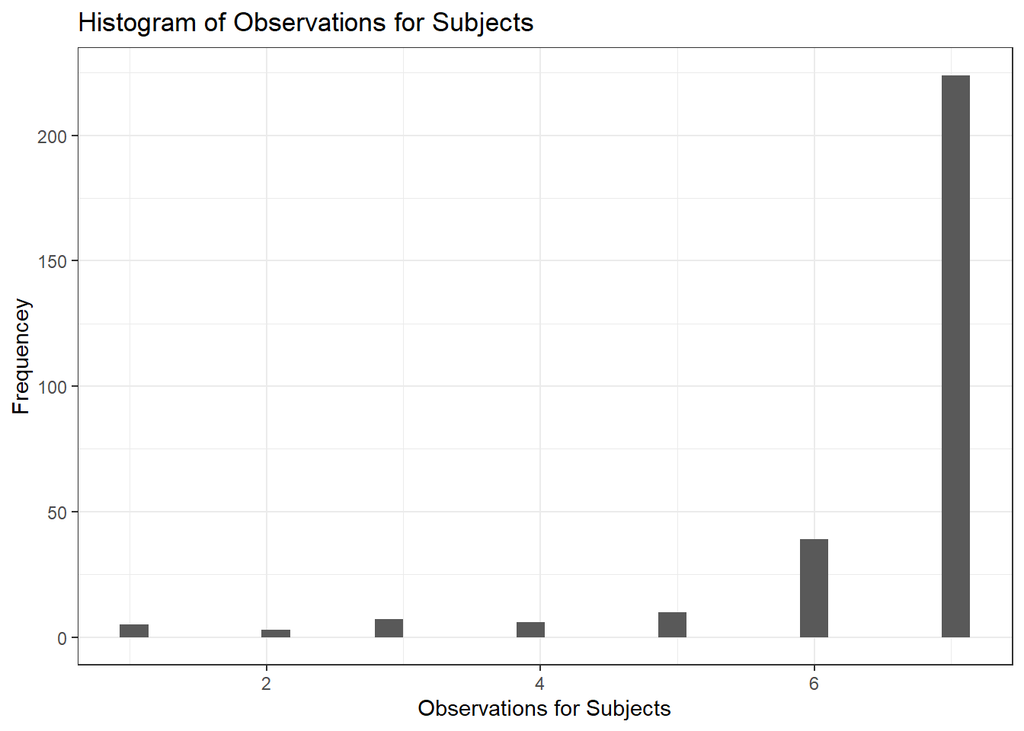

The above plot shows the number of observations for individual subjects.

#### Part D

Write up the model notation for the AR(1) model. Include the outcome, expected value of the outcome, variance of the outcome, and pairwise correlation function, systematic component specific to your model, and the link function. Define all subscripts (i’s and j’s, number of people, observations on a person).

Outcome:
$$Y_{ij} \sim
Bernoulli(\mu_{ij})$$
Expected Value:
$$E[Y_{ij}] = \mu_{ij}$$
Variance:
$$Var[Y_{ij}] = \mu_{ij}(1-\mu_{ij})$$
Pairwise Correlation:
$$Corr(Y_{ij},Y_{ik})=
\alpha^{|k-j|}$$
Systematic Component:
$$\eta_{ij} = \beta_0 + \beta_{Month}Month_{ij} +
\beta_{Trt:Month}Trt_{ij}Month_{ij} + \epsilon_{ij}$$
Link Function:
$$\eta_{ij} =
log\left(\frac{\mu_{ij}}{1-\mu_{ij}}\right)$$
$$i = 1...n;n=Number\,\,of\,\,subjects$$
$$j=1...n_i;n_i =
Number\,\,of\,\,Observations\,\,for\,\,a\,\,subject.$$

## Question 5

Epileptic Seizure Study of a randomized trail reported in Thall and Vail (1990). -59 subjects with epilepsy suffering from simple or partial seizures were assigned at random to receive either the anti-epileptic drug progabide or a placebo in addition to a standard chemotherapy regimen all were taken. Fit a marginal GEE model to assess whether treatment modifies the time pattern.

#### Part A

What time trend do you want to use to model visit? Investigate several different approaches and justify.

1. Factored visit: Factoring visit will give the change between each visit as time progresses. In this scenario visit 0 would be the reference group against each subsequent 2 weeks of treatment. The benefit of this approach is that we can see how each individual visit relates to the baseline visit. Age and treatment will controlled in this model and an offset will be included. The correlation structure is independent.

```r
## START QUESTION 5 PART A CODE ##

seizure_fac_visit <- geem2(seize ~ trt + factor(visit) + age + offset(logo),
                           data = dat.sz, id = dat.sz$subj,
                           family = poisson(link = "log"))

summary(seizure_fac_visit)
```

```
##                Estimate Model SE Robust SE    Wald         p
## (Intercept)     1.93656  0.35039   0.54866  3.5296 0.0004162
## trt1           -0.05287  0.14134   0.25837 -0.2046 0.8378590
## factor(visit)1  0.13678  0.21326   0.14256  0.9595 0.3373229
## factor(visit)2  0.06820  0.21907   0.08955  0.7616 0.4463178
## factor(visit)3  0.07829  0.21820   0.16379  0.4780 0.6326762
## factor(visit)4 -0.06620  0.23116   0.09766 -0.6779 0.4978349
## age            -0.01957  0.01156   0.02042 -0.9583 0.3379102
##
##  Estimated Correlation Parameter:  0
##  Correlation Structure:  independence
##  Est. Scale Parameter:  18.66
##
##  Number of GEE iterations: 2
##  Number of Clusters:  59    Maximum Cluster Size:  5
##  Number of observations with nonzero weight:  295
```

2. Continuous visit with an offset: A model where visit is considered continuous will be modeled next. The advantage of this model is that there is only one visit coefficient, making interpretation a little easier. Age and treatment will be controlled for and an offset will be included. The correlation structure will be independent.

```r
seizure_cont_visit <- geem2(seize ~ trt + visit + age + offset(logo),
                            data = dat.sz, id = dat.sz$subj,
                            family = poisson(link = "log"))

summary(seizure_cont_visit)
```

```
##               Estimate Model SE Robust SE     Wald         p
## (Intercept)  1.9666621  0.35162   0.55478  3.54496 0.0003927
## trt1        -0.0528702  0.14283   0.25837 -0.20463 0.8378590
## visit       -0.0009649  0.04796   0.02999 -0.03218 0.9743312
## age         -0.0195680  0.01168   0.02042 -0.95830 0.3379102
##
##  Estimated Correlation Parameter:  0
##  Correlation Structure:  independence
##  Est. Scale Parameter:  19.06
##
##  Number of GEE iterations: 2
##  Number of Clusters:  59    Maximum Cluster Size:  5
##  Number of observations with nonzero weight:  295
```

3. Continuous visit with a squared term: A squared term may fit the data better. Age and treatment will be controlled for and an offset will be included. The correlation structure will again be independent.

```r
seizure_cont_visit_sq <- geem2(seize ~ trt + visit + I(visit^2) + age + offset(logo),
                            data = dat.sz, id = dat.sz$subj,
                            family = poisson(link = "log"))

summary(seizure_cont_visit_sq)
```

```
##             Estimate Model SE Robust SE    Wald         p
## (Intercept)  1.94038  0.35027   0.55098  3.5217 0.0004288
## trt1        -0.05287  0.14151   0.25837 -0.2046 0.8378590
## visit        0.12697  0.17047   0.09877  1.2856 0.1986001
## I(visit^2)  -0.03603  0.04630   0.02114 -1.7048 0.0882301
## age         -0.01957  0.01158   0.02042 -0.9583 0.3379102
##
##  Estimated Correlation Parameter:  0
##  Correlation Structure:  independence
##  Est. Scale Parameter:  18.71
##
##  Number of GEE iterations: 2
##  Number of Clusters:  59    Maximum Cluster Size:  5
##  Number of observations with nonzero weight:  295
```

```r
seizure_cont_visit_ar1 <- geem2(seize ~ trt + age + offset(logo),
                            data = dat.sz, id = dat.sz$subj,
                            family = poisson(link = "log"), corstr = "ar1")

summary(seizure_cont_visit_ar1)
```

```
##              Estimate Model SE Robust SE     Wald         p
## (Intercept)  2.408342  0.46694   0.44282  5.43866 5.000e-08
## trt1         0.005207  0.19182   0.20285  0.02567 9.795e-01
## age         -0.040494  0.01611   0.01451 -2.79112 5.253e-03
##
##  Estimated Correlation Parameter:  0.8117
##  Correlation Structure:  ar1
##  Est. Scale Parameter:  21.09
##
##  Number of GEE iterations: 4
##  Number of Clusters:  59    Maximum Cluster Size:  5
##  Number of observations with nonzero weight:  295
```

```r
## FINISH QUESTION 5 PART A CODE ##
```

#### Part B

Do you need an offset for this model? Explain how you figured that out.

In this model an offset should be included. Visit 0 incorporating 8 weeks would over inflate the number of seizures for this time point.

#### Part C

Do you see any evidence of a need for over dispersion based on summary statistics (mean and variance summary measures)?

Summary Statistics: Seizure Data

|  | 0 0 (N=28) | 0 1 (N=31) | 1 0 (N=28) | 1 1 (N=31) | 2 0 (N=28) | 2 1 (N=31) | 3 0 (N=28) | 3 1 (N=31) | 4 0 (N=28) | 4 1 (N=31) | Overall 0 (N=140) | Overall 1 (N=155) |
| --- | --- | --- | --- | --- | --- | --- | --- | --- | --- | --- | --- | --- |
| seize |  |  |  |  |  |  |  |  |  |  |  |  |
| Mean (SD) | 30.8 (26.1) | 31.6 (28.0) | 9.36 (10.1) | 8.58 (18.2) | 8.29 (8.16) | 8.42 (11.9) | 8.79 (14.7) | 8.13 (13.9) | 7.96 (7.63) | 6.71 (11.3) | 13.0 (17.3) | 12.7 (19.9) |
| Median [Min, Max] | 19.0 [6.00, 111] | 24.0 [7.00, 151] | 5.00 [0, 40.0] | 4.00 [0, 102] | 4.50 [0, 29.0] | 5.00 [0, 65.0] | 5.00 [0, 76.0] | 4.00 [0, 72.0] | 5.00 [0, 29.0] | 4.00 [0, 63.0] | 6.00 [0, 111] | 6.00 [0, 151] |

From the summary table we will need to account for overdispersion, as the variance is significantly larger than the mean.

#### Part D

Do you actually need to incorporate overdispersion in a GEE model? Explain.

In general no you do not need to incorporate overdispersion in a GEE model. The GEE model already has a quasi-likelihood, and can incorporate the overdispersion that exists in the data set.

#### Part E

Fit a marginal GEE model to these data with treatment, linear time, and an interaction with treatment and time. Provide code and summary output.

```r
## START QUESTION 5 PART E CODE ##

# Fitting a GEE model for the number of seizures.
seizure_mod <- geem2(seize ~ trt + visit + age + trt:visit + offset(logo), data = dat.sz,
                     id = dat.sz$subj, family = poisson(link = "log"))

summary(seizure_mod)
```

```
##              Estimate Model SE Robust SE     Wald         p
## (Intercept)  1.941901  0.35844   0.56890  3.41343 0.0006415
## trt1        -0.005428  0.18702   0.22361 -0.02428 0.9806324
## visit        0.018542  0.06860   0.03996  0.46406 0.6426019
## age         -0.019568  0.01171   0.02042 -0.95830 0.3379102
## trt1:visit  -0.037979  0.09619   0.06140 -0.61859 0.5361870
##
##  Estimated Correlation Parameter:  0
##  Correlation Structure:  independence
##  Est. Scale Parameter:  19.15
##
##  Number of GEE iterations: 2
##  Number of Clusters:  59    Maximum Cluster Size:  5
##  Number of observations with nonzero weight:  295
```

```r
## FINISH QUESTION 5 PART E CODE ##
```

#### PART F

Test whether there is an interaction between time and treatment and interpret the interaction if it is significant. If not, refit the model removing the interaction and interpret the model with just the main effects. Include point estimates, 95% CI, and p-values with statistical conclusions.

The p-value for the interaction term is 0.536, meaning that it is not significant. If it were significant the interpretation would be the difference in expected seizures as visit increases for treatment compared to the placebo. In other words if the interaction had been significant it would incorporate the additional decrease in seizures for the treatment group as visits number increased.

```
##               Estimate Model SE Robust SE     Wald         p
## (Intercept)  1.9666621  0.35162   0.55478  3.54496 0.0003927
## trt1        -0.0528702  0.14283   0.25837 -0.20463 0.8378590
## visit       -0.0009649  0.04796   0.02999 -0.03218 0.9743312
## age         -0.0195680  0.01168   0.02042 -0.95830 0.3379102
##
##  Estimated Correlation Parameter:  0
##  Correlation Structure:  independence
##  Est. Scale Parameter:  19.06
##
##  Number of GEE iterations: 2
##  Number of Clusters:  59    Maximum Cluster Size:  5
##  Number of observations with nonzero weight:  295
```

# Code

```r
library(tidyverse)
library(mmmgee)
library(kableExtra)
library(table1)


### START QUESTION 4 CODE ###

## START QUESTION 4 PART A ##

# Reading in data.
onycholysis_data_raw <- read_table("C:/Users/domin/Documents/Biostatistics Masters Program/Fall 2023/BIOS 6643 - ADL/BIOS6643_ALD/Homework 7/toenail-data.txt")

onycholysis_data <- onycholysis_data_raw %>%
  mutate(treat = factor(treat))

# geem2 was saying id not the same dimension as the data frame. I extracted
# out the ids as a vector and set that for the id parameter in geem2.
id_vector <- onycholysis_data$id


onycholysis_ar1 <- geem2(response ~ month + treat:month, id = id_vector,
                        data = onycholysis_data,
                        family = binomial(link = "logit"),
                        corstr = "ar1", init.phi = 1, scale.fix = TRUE)

onycholysis_ar1_sum <- summary(onycholysis_ar1)

# 95% CI for the month estimate.
month_lower <- exp(onycholysis_ar1_sum$coef[2,1] -
                     onycholysis_ar1_sum$coef[2,3]*1.96)

month_upper <- exp(onycholysis_ar1_sum$coef[2,1] +
                     onycholysis_ar1_sum$coef[2,3]*1.96)

# 95% CI for the month:treat1 coefficient.
month_trt_lower <- exp(onycholysis_ar1_sum$coef[3,1] -
                         onycholysis_ar1_sum$coef[3,3]*1.96)

month_trt_upper <- exp(onycholysis_ar1_sum$coef[3,1] +
                         onycholysis_ar1_sum$coef[3,3]*1.96)

onycholysis_ar1_sum


onycholysis_ind <- geem2(response ~ month + treat:month, id = id_vector,
                        data = onycholysis_data,
                        family = binomial(link = "logit"),
                        corstr = "independence", init.phi = 1, scale.fix = TRUE)

onycholysis_ind_sum <- summary(onycholysis_ind)

onycholysis_ind_sum


onycholysis_exch <- geem2(response ~ month + treat:month, id = id_vector,
                        data = onycholysis_data,
                        family = binomial(link = "logit"),
                        corstr = "exchangeable", init.phi = 1, scale.fix = TRUE)

onycholysis_exch_sum <- summary(onycholysis_exch)

onycholysis_exch_sum

## FINISH QUESTION 4 PART A CODE ##


## START QUESTION 4 PART B CODE ##

efficiency_df <- data.frame(term = c("Beta_0","Beta_month",
                                     "Beta_trt:month"),
                            ar_1 = c(0.12592,0.02587,0.04495),
                            independence = c(0.12524,0.02917,0.04753),
                            exchangeable = c(0.13039,0.02956,0.05378))

efficiency_df <- kbl(efficiency_df,
                     caption = "Robust Standard Errors",
                     col.names = c("Term","AR(1)","Independence",
                                   "Exchangeable"),
                     booktabs = T, align = "cc") %>%
  kable_styling(latex_options = "HOLD_position")

efficiency_df

## FINISH QUESTION 4 PART B CODE ##


## START QUESTION 4 PART C CODE ##

obs_count <- onycholysis_data %>% dplyr::group_by(id) %>% summarise(Count = n())

obs_count_plot <- ggplot(obs_count, aes(x = Count)) +
  geom_histogram() +
  labs(title = "Histogram of Observations for Subjects",
       x = "Observations for Subjects", y = "Frequencey") +
  theme_bw()

obs_count_plot

## FINISH QUESTION 4 PART C CODE ##

### FINISH QUESTION 4 CODE ###


### START QUESTION 5 CODE

# Data location:
# Desktop: "C:/Users/domin/Documents/Biostatistics Masters Program/Fall 2023/BIOS 6643 - ADL/BIOS6643_ALD/Homework 7/epilepsy.txt"
# Laptop: "C:/Users/domin/Documents/Biostatistics Masters Program/Fall 2023/BIOS 6643 - ADL/BIOS6643_ALD/Homework 7/epilepsy.txt"

dat.sz_raw <- read_table("C:/Users/domin/Documents/Biostatistics Masters Program/Fall 2023/BIOS 6643 - ADL/BIOS6643_ALD/Homework 7/epilepsy.txt")

# Factoring the trt variable.
dat.sz <- dat.sz_raw %>% mutate(trt = factor(trt))

# Creating other covariates. dat.sz$o is the number of weeeks in the observation
# time (8 weeks or 2 weeks).
dat.sz$o <- 8*(dat.sz$visit==0)+2*(dat.sz$visit>0)

# Creates an offset for the difference in the number of weeks for each obs.
dat.sz$logo <- log(dat.sz$o)
dat.sz$vm0 <- as.numeric(dat.sz$visit>0)



## START QUESTION 5 PART A CODE ##

seizure_fac_visit <- geem2(seize ~ trt + factor(visit) + age + offset(logo),
                           data = dat.sz, id = dat.sz$subj,
                           family = poisson(link = "log"))

summary(seizure_fac_visit)


seizure_cont_visit <- geem2(seize ~ trt + visit + age + offset(logo),
                            data = dat.sz, id = dat.sz$subj,
                            family = poisson(link = "log"))

summary(seizure_cont_visit)


seizure_cont_visit_sq <- geem2(seize ~ trt + visit + I(visit^2) + age + offset(logo),
                            data = dat.sz, id = dat.sz$subj,
                            family = poisson(link = "log"))

summary(seizure_cont_visit_sq)


seizure_cont_visit_ar1 <- geem2(seize ~ trt + age + offset(logo),
                            data = dat.sz, id = dat.sz$subj,
                            family = poisson(link = "log"), corstr = "ar1")

summary(seizure_cont_visit_ar1)

## FINISH QUESTION 5 PART A CODE ##


## START QUESTION 5 PART C CODE ##

seizure_summary <- table1(~ seize | visit*trt, dat.sz,
                          caption = "Summary Statistics: Seizure Data")

seizure_summary

## FINISHE QUESTION 5 PART C CODE ##


## START QUESTION 5 PART E CODE ##

# Fitting a GEE model for the number of seizures.
seizure_mod <- geem2(seize ~ trt + visit + age + trt:visit + offset(logo), data = dat.sz,
                     id = dat.sz$subj, family = poisson(link = "log"))

summary(seizure_mod)

## FINISH QUESTION 5 PART E CODE ##


## START QUESTION 5 PART F CODE ##

# Model which excludes the interaction term.
seizure_mod2 <- geem2(seize ~ trt + visit + age + offset(logo), data = dat.sz,
                     id = dat.sz$subj, family = poisson(link = "log"))

seizure_mod2_sum <- summary(seizure_mod2)

# Calculating the treatment rate and confidence intervals.
trt_rate <- exp(seizure_mod2_sum$coef[2,1])

trt_lower <- exp(seizure_mod2_sum$coef[2,1] - seizure_mod2_sum$coef[2,3]*1.96)

trt_upper <- exp(seizure_mod2_sum$coef[2,1] + seizure_mod2_sum$coef[2,3]*1.96)

# Calculating the visit rate and confidence intervals.
visit_rate <- exp(seizure_mod2_sum$coef[3,1])

visit_lower <- exp(seizure_mod2_sum$coef[3,1] - seizure_mod2_sum$coef[3,3]*1.96)

visit_upper <- exp(seizure_mod2_sum$coef[3,1] + seizure_mod2_sum$coef[3,3]*1.96)

seizure_mod2_sum

# Calculating the age rate and confidence intervals.
age_rate <- exp(seizure_mod2_sum$coef[4,1])

age_lower <- exp(seizure_mod2_sum$coef[4,1] - seizure_mod2_sum$coef[4,3]*1.96)

age_upper <- exp(seizure_mod2_sum$coef[4,1] + seizure_mod2_sum$coef[4,3]*1.96)


## FINISH QUESTION 5 PART F CODE ##

### FINISH QUESTION 5 CODE ###
```